# HW2-8

**Data Loading**

```r
income_data = read.csv("Income_Data.txt", header=FALSE, quote=NULL)
```

1. ANNUAL INCOME OF HOUSEHOLD (Numerical)
2. SEX (Categorial)
3. MARITAL STATUS (Categorial)
4. AGE (Numerical)
5. EDUCATION (Numerical)
6. OCCUPATION (Categorial)
7. HOW LONG HAVE YOU LIVED IN THE SAN FRAN./OAKLAND/SAN JOSE AREA? (Numerical)
8. DUAL INCOMES (IF MARRIED) (Categorial)
9. PERSONS IN YOUR HOUSEHOLD (Numerical)
10. PERSONS IN HOUSEHOLD UNDER 18 (Numerical)
11. HOUSEHOLDER STATUS (Categorial)
12. TYPE OF HOME (Categorial)
13. ETHNIC CLASSIFICATION (Categorial)
14. WHAT LANGUAGE IS SPOKEN MOST OFTEN IN YOUR HOME? (Categorial)

```r
cname = c("income","sex","marital_status","age","education","occupation","how_long_live","dual_imcome","persons_in_household","persons_under_18","householder_status","home_type","ethnic","language")
colnames(income_data) = cname
income_data[, 1] = as.numeric(income_data[, 1])
income_data[, 2] = as.factor(income_data[, 2])
income_data[, 3] = as.factor(income_data[, 3])
income_data[, 4] = as.numeric(income_data[, 4])
income_data[, 5] = as.numeric(income_data[, 5])
income_data[, 6] = as.factor(income_data[, 6])
income_data[, 7] = as.numeric(income_data[, 7])
income_data[, 8] = as.factor(income_data[, 8])
income_data[, 9] = as.numeric(income_data[, 9])
income_data[, 10] = as.numeric(income_data[, 10])
income_data[, 11] = as.factor(income_data[, 11])
income_data[, 12] = as.factor(income_data[, 12])
income_data[, 13] = as.factor(income_data[, 13])
income_data[, 14] = as.factor(income_data[, 14])
# Dividing the data into train - 70% and test - 30%
set.seed(123)
train = sample(1:nrow(income_data), nrow(income_data)*0.7)
incomeData.train = income_data[train,]
incomeData.test = income_data[-train,]
```

**Package Loading**

```r
library(gbm)
```

**gbm function calling**

```r
set.seed(444) # Random for bag.fraction
gbm0 <- gbm(income~., data = incomeData.train, train.fraction = 0.8, interaction.depth = 4, shrinkage = .05, n.trees = 2500, bag.fraction = 0.5, cv.folds = 5, distribution = "gaussian", verbose = T)
```

```
     1        7.4350          7.5104     0.0500    0.2928
     2        7.1655          7.2500     0.0500    0.2656
     3        6.9202          7.0134     0.0500    0.2453
     4        6.6926          6.7905     0.0500    0.2165
     5        6.4861          6.5920     0.0500    0.2046
     6        6.2917          6.4042     0.0500    0.1913
     7        6.1134          6.2324     0.0500    0.1735
     8        5.9494          6.0710     0.0500    0.1516
     9        5.8040          5.9261     0.0500    0.1428
    10        5.6678          5.7969     0.0500    0.1316
    20        4.7268          4.8951     0.0500    0.0598
    40        4.0585          4.2626     0.0500    0.0173
    60        3.8105          4.0697     0.0500    0.0035
    80        3.6857          3.9955     0.0500    0.0003
   100        3.6102          3.9657     0.0500   -0.0006
```

[output cut: 120 more lines]

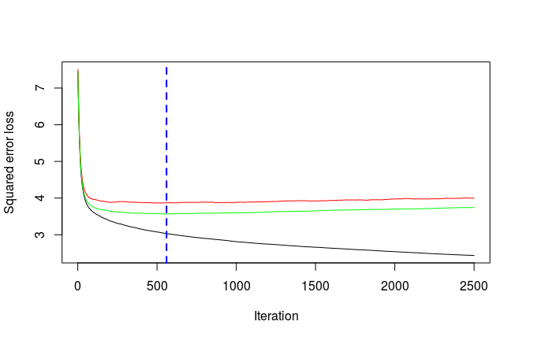

```r
best.iter_train <- gbm.perf(gbm0, method = "cv")
```

```r
# For test data
gbm0.prediction <- predict(gbm0, incomeData.test, type ="response", n.trees = best.iter_train)
sqrt(mean((incomeData.test$income - gbm0.prediction)^2))
```

```
[1] 1.941994
```

Compared to 2.063451, the loss decreases.

|  | var | rel.inf |
| --- | --- | --- |
| occupation | occupation | 22.8297137 |
| age | age | 18.2128611 |
| householder_status | householder_status | 17.2466076 |
| marital_status | marital_status | 15.2228539 |
| education | education | 8.1316748 |
| home_type | home_type | 4.1992535 |
| ethnic | ethnic | 3.9123971 |
| persons_in_household | persons_in_household | 3.3793838 |
| how_long_live | how_long_live | 1.9618461 |
| dual_imcome | dual_imcome | 1.8662114 |

[output cut: 3 more lines]

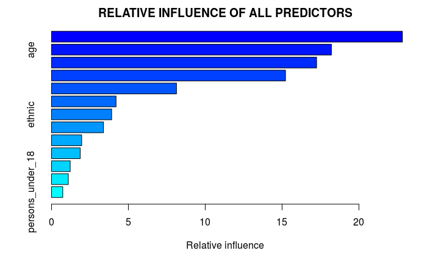

```r
summary(gbm0, n.tree = best.iter_train, main="RELATIVE INFLUENCE OF ALL PREDICTORS")
```

The fact that influence of ‘sex’ is low does not conflict with US averages. According to `Income_Info.txt`, the survey was conducted for shopping mall customers in the San Fransisco Bay area. Because it is a fairly local survey, the sample will not represent the US average.

In addition, the income dependent on the house is about the family rather than the individual. There is both woman and man in a family, so the standard of house income is not personalized.